# Тестирование успеваемости

### Новый способ подсчёта сложности домашних работ

```python
###

import pandas as pd
import numpy as np
from matplotlib import pyplot as plt
import seaborn as sns
import re
from scipy import stats

import statsmodels.api as sm


df_list = []
for i in range(1,5):
    df_list.append(pd.read_csv(f'hw_mat_{i}.csv'))

df = pd.concat(df_list)

df = df.rename(columns = {'ID':'id',
        'Урок':'lesson',
        'Продукты':'products' ,
        'Результаты':'total_result',
        'ID номера':'task_id',
        'Баллы за ответ ученика':'stud_answer',
       'Максимальное кол-во баллов за данную задачу':'task_mpoint'})[['id','products','lesson','total_result','task_id','stud_answer','task_mpoint']]


df['products'] = df['products'].str.split(' с ').str[-1].str.split(' 2').str[0]
df['lesson'] = pd.Categorical(df['lesson']).codes
df['task_id'] = df['task_id'].str.split('\n').str[0:-1]
df['stud_answer'] = df['stud_answer'].str.split('\n').str[0:-1]
df['task_mpoint'] = df['task_mpoint'].str.split('\n').str[0:-1]
df = pd.concat([df.explode('task_id')[['id','products','lesson','total_result','task_id']], df.explode('stud_answer')['stud_answer'], df.explode('task_mpoint')['task_mpoint']], axis = 1)
df = df.dropna()
df['stud_answer'] = df['stud_answer'].astype(int)
df['task_mpoint'] = df['task_mpoint'].astype(int)
df = df.query('task_mpoint>0')
df['stud_percent'] = df['stud_answer'].astype(int)/df['task_mpoint'].astype(int)
```

- мы объединяем все домашки за данный месяц, вне зависимости от того были ли ученики при этом в Про/Стандарт/Хард

```python
df['products'] = df['products'].apply(lambda x: ''.join(re.split(' \\((Хард|Про|Стандарт|Премиум|Бесплатный|Про NEO|Премиум NEO|Стандарт NEO|Хард NEO)\\) ',x)[0:3:2]))
```

### Устройство рабочей таблицы

- id - идентефикационный номер ученика
- products - классификационный номер продукты
- lesson - классификационный номер урока
- task_id - ID задачи
- total_result - результат ученика за данную домашку
- stud_answer - результат ученика за данный номер в домашке
- task_mpoint - максимальный балл, который можно получить за решение данного номера
- stud_percent - процент набранных баллов за задачу

```python
df
```

|  | id | products | lesson | total_result | task_id | stud_answer | task_mpoint | stud_percent |
| --- | --- | --- | --- | --- | --- | --- | --- | --- |
| 0 | 52866741 | Аделией— Сентябрь | 81 | 17 | 120945 | 1 | 1 | 1.0 |
| 0 | 52866741 | Аделией— Сентябрь | 81 | 17 | 120947 | 0 | 1 | 0.0 |
| 0 | 52866741 | Аделией— Сентябрь | 81 | 17 | 120948 | 0 | 1 | 0.0 |
| 0 | 52866741 | Аделией— Сентябрь | 81 | 17 | 120949 | 0 | 1 | 0.0 |
| 0 | 52866741 | Аделией— Сентябрь | 81 | 17 | 120950 | 0 | 1 | 0.0 |
| ... | ... | ... | ... | ... | ... | ... | ... | ... |
| 87024 | 60193995 | Артуром— Ноябрь | 47 | 20 | 142692 | 2 | 2 | 1.0 |
| 87024 | 60193995 | Артуром— Ноябрь | 47 | 20 | 142703 | 0 | 2 | 0.0 |
| 87024 | 60193995 | Артуром— Ноябрь | 47 | 20 | 142706 | 0 | 2 | 0.0 |
| 87024 | 60193995 | Артуром— Ноябрь | 47 | 20 | 142711 | 0 | 2 | 0.0 |
| 87024 | 60193995 | Артуром— Ноябрь | 47 | 20 | 142719 | 0 | 2 | 0.0 |

2912202 rows × 8 columns

### Сгруппированная таблица

- Для решения задачи мы должны сгруппировать данные. Мы группируем их по products и lesson. А по остальным столбцам будем подсчитывать какой-то усреднённый результат
- mean_stud_points - среднее количество баллов набранных учеником в данной домашке
- mean_stud_percent - средний процент выполнения заданий в данной домашке среди всех задач
- all_stud_points - общее количество баллов, которые набрал ученик в данной домашке
- all_max_points - общий максимальный баллл, всех задач в домашке

```python
grouped_df = df[['id','products','lesson','stud_answer','stud_percent','task_mpoint']].groupby(
    ['products','lesson', 'id']).agg(
    mean_stud_points=('stud_answer',np.mean),
    mean_stud_percent = ('stud_percent', np.mean),
    all_stud_points = ('stud_answer', np.sum),
    all_max_points=('task_mpoint',np.sum)).droplevel('id')
```

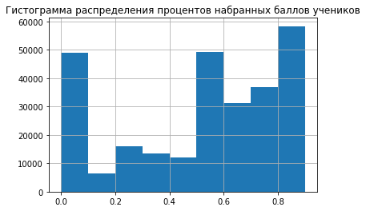

```python
grouped_df['mean_stud_percent'].hist(bins = np.arange(0,1,0.1))
plt.title( 'Гистограмма распределения процентов набранных баллов учеников')
plt.show()
```

- Гистограмма выше показывает, что сради набранных учениками "процентов" превалирует 1 и 0, а так же другие величины в середине. То есть речь не идёт о каком-то равномерном распределении процентов.
- Поэтому на основе данных выше, мы подсчитываем следующие величины: $$ complexity_1 = 1- \frac{(mean - std)}{(mean+std)} $$

$$ complexity_2 = 1- \frac{(mean)}{(mean+std)} $$$$ complexity_3 = 1- \frac{(mean - std)}{(mean)} $$

- mean - это средний процент набора учениками баллов за данную домашку: $$ mean = \sum \frac{p_i}{N} $$ здесь $p_i$ - это средний процент отдельного ученика решившего домашку
- std - это стандартное отклонение процентов учеников, от среднего значения: $$ std = \sum \sqrt{\frac{(p_i - mean)^2}{N}} $$

```python
gr2_df = grouped_df.reset_index().groupby(['products','lesson']).agg(std_percent = ('mean_stud_percent',np.std),mean_percent = ('mean_stud_percent',np.mean))
gr2_df['complexity_1'] = 1- (gr2_df['mean_percent']-gr2_df['std_percent'])/(gr2_df['mean_percent']+gr2_df['std_percent'])
gr2_df['complexity_2'] = 1- (gr2_df['mean_percent'])/(gr2_df['mean_percent']+gr2_df['std_percent'])
gr2_df['complexity_3'] = 1- (gr2_df['mean_percent']-gr2_df['std_percent'])/(gr2_df['mean_percent'])

gr2_df.dropna().sort_values(by = 'mean_percent').head(10)
```

| products | lesson | std_percent | mean_percent | complexity_1 | complexity_2 | complexity_3 |
| --- | --- | --- | --- | --- | --- | --- |
| Аделией— Март | 32 | 0.242536 | 0.058824 | 1.609612 | 0.804806 | 4.123106 |
| Андреем— Апрель | 201 | 0.165831 | 0.060000 | 1.468630 | 0.734315 | 2.763854 |
| Аделией— Апрель | 28 | 0.250000 | 0.125000 | 1.333333 | 0.666667 | 2.000000 |
| Андреем— Март | 431 | 0.355773 | 0.147287 | 1.414436 | 0.707218 | 2.415513 |
| Аделией— Февраль | 30 | 0.094277 | 0.153521 | 0.760920 | 0.380460 | 0.614100 |
| Артуром— Февраль | 599 | 0.232166 | 0.158446 | 1.188729 | 0.594364 | 1.465267 |
| Аделией— Апрель | 269 | 0.235702 | 0.166667 | 1.171573 | 0.585786 | 1.414214 |
| Аделией— Февраль | 488 | 0.324883 | 0.206522 | 1.222733 | 0.611367 | 1.573119 |
| Андреем— Январь | 534 | 0.294750 | 0.212010 | 1.163274 | 0.581637 | 1.390268 |
| Андреем— Октябрь | 113 | 0.183005 | 0.217033 | 0.914939 | 0.457470 | 0.843215 |

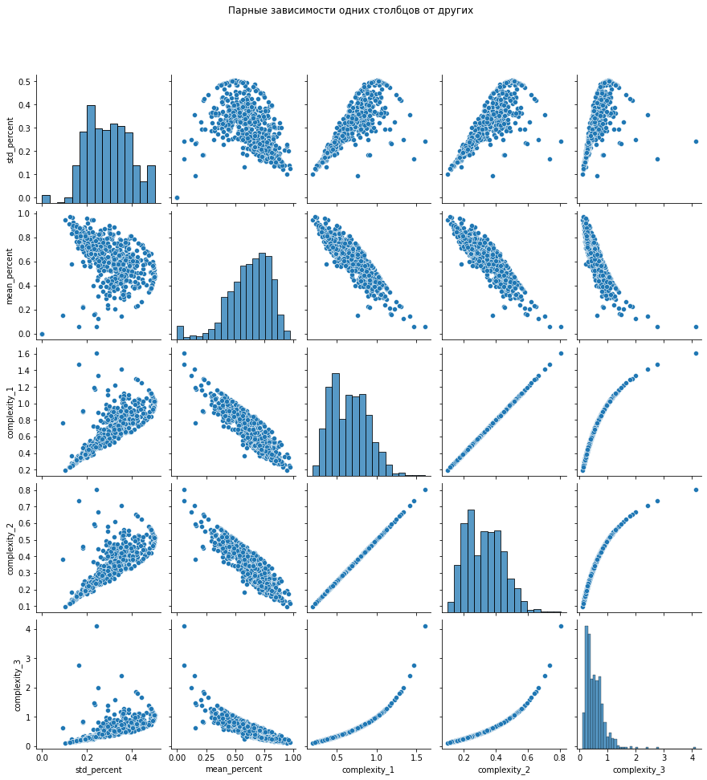

```python
pair_plot = sns.pairplot(gr2_df)
pair_plot.fig.suptitle('Парные зависимости одних столбцов от других', y = 1.08)
```

### Проверка гипотезы о нормальности распределения сложности заданий.

- Для чего это нужно? Ожидается, что курс, какой бы он ни был, должен иметь нормальное распределение сложности: мало сложных домашек, мало лёгких. Если это не так, то это будет говорить о том, что курс не сбалансированный
- Если сделать предположение о том, что курс математики сбалансирован, тогда распределение функции которая отражает его сложность, должна быть нормальной
- Проверку нормальности я буду проводить статистическими методами. В частности методом построения qq-plot
- Петод qq-plot состоит в том, чтобы построить "предполагаемое распределение" и реальное распределение, а затем по точкам построить график зависимости одного от друого. Чем ближе такой грфик к диагонали - тем сильноее выражена "нормальность" исследуемого распределения

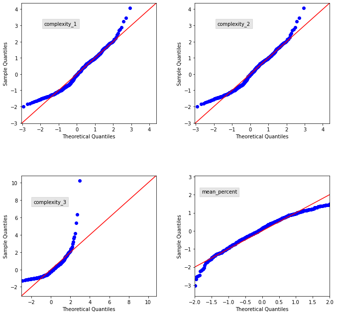

```python
left = -1.8   #x coordinate for text insert

fig = plt.figure()

ax = fig.add_subplot(2, 2, 1)
sm.graphics.qqplot(gr2_df['complexity_1'].dropna(),line='45', fit=True, ax=ax)
top = ax.get_ylim()[1] * 0.75
txt = ax.text(left, top, 'complexity_1', verticalalignment='top')
txt.set_bbox(dict(facecolor='k', alpha=0.1))

ax = fig.add_subplot(2, 2, 2)
sm.graphics.qqplot(gr2_df['complexity_2'].dropna(), line='45', fit=True, ax=ax)
top = ax.get_ylim()[1] * 0.75
txt = ax.text(left, top, "complexity_2", verticalalignment='top')
txt.set_bbox(dict(facecolor='k', alpha=0.1))

ax = fig.add_subplot(2, 2, 3)
sm.graphics.qqplot(gr2_df['complexity_3'].dropna(), line='45', fit=True, ax=ax)
#ax.set_xlim(-2, 2)
top = ax.get_ylim()[1] * 0.75
txt = ax.text(left, top, "complexity_3", verticalalignment='top')
txt.set_bbox(dict(facecolor='k', alpha=0.1))

ax = fig.add_subplot(2, 2, 4)
sm.graphics.qqplot(gr2_df['mean_percent'].dropna(), line='45', fit=True, ax=ax)
ax.set_xlim(-2, 2)
top = ax.get_ylim()[1] * 0.75
txt = ax.text(left, top, "mean_percent",
              verticalalignment='top')
txt.set_bbox(dict(facecolor='k', alpha=0.1))

fig.tight_layout()
fig.set_figheight(10)
fig.set_figwidth(10)
```

- Наша оценка "на глаз" была близка к правде. complexity_1 и complexity_2 имеют гораздо более выраженную нормальность, чем complexity_3
- Далее мы будем исследовать только complexity_2. Он находится в пределах от 0 до 1, а значит более просто интерпретируем.

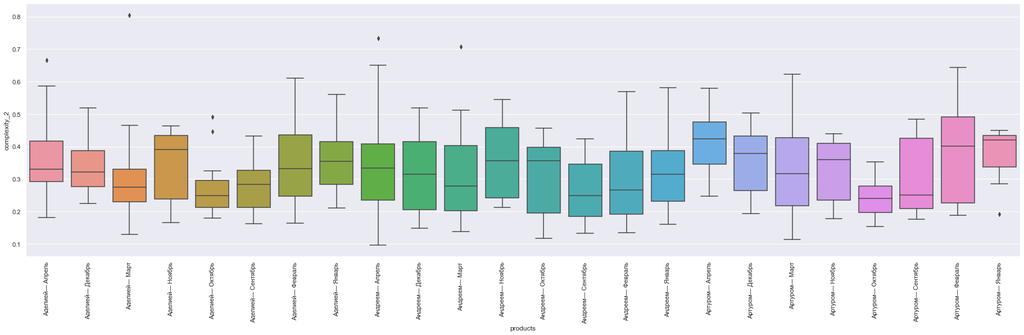

```python
ax = sns.boxplot(x = "products", y="complexity_2",
                 data=gr2_df.reset_index().sort_values(by = 'products'))
sns.set(rc={'figure.figsize':(31.7,8.27)})
aray_of_ticks = plt.xticks(rotation=90)
```

- Выше приведён график, который отражает среднюю распределение сложности по продуктам.
- "Свеча" каких-то продуктов более растянута, а значит в них встречаются и сложные и простые домашки
- Продукты, у которых вместо свечи только одна линия - либо содержат не много домашек, либо все домашки имеют близкую к одному значению сложность
- Отдельные точки выше и ниже свечек - это "выбросы", то есть какие-то экстроординарные по своей сложности/лёгкости уроки.
- К несчастью график сортируется по алфавитному порядку, а не по номеру месяца. но мы сейчас это исправим

```python
gr2_df
```

| products | lesson | std_percent | mean_percent | complexity_1 | complexity_2 | complexity_3 |
| --- | --- | --- | --- | --- | --- | --- |
| Аделией— Апрель | 28 | 0.250000 | 0.125000 | 1.333333 | 0.666667 | 2.000000 |
|  | 29 | 0.270124 | 0.628571 | 0.601147 | 0.300574 | 0.429743 |
|  | 39 | 0.225976 | 0.664286 | 0.507661 | 0.253831 | 0.340178 |
|  | 58 | 0.179918 | 0.812254 | 0.362676 | 0.181338 | 0.221505 |
|  | 59 | 0.240691 | 0.687831 | 0.518438 | 0.259219 | 0.349927 |
| ... | ... | ... | ... | ... | ... | ... |
| Артуром— Январь | 531 | 0.353102 | 0.485431 | 0.842189 | 0.421094 | 0.727398 |
|  | 567 | 0.397012 | 0.486803 | 0.898406 | 0.449203 | 0.815551 |
|  | 607 | 0.421299 | 0.564121 | 0.855066 | 0.427533 | 0.746825 |
|  | 660 | 0.343736 | 0.651688 | 0.690632 | 0.345316 | 0.527455 |
|  | 716 | 0.406293 | 0.661390 | 0.761074 | 0.380537 | 0.614302 |

608 rows × 5 columns

```python
month_names = {'Сентябрь':1, 'Октябрь':2,'Ноябрь':3,'Декабрь':4,'Январь':5,'Февраль':6, 'Март':7, 'Апрель':8}
gr3_df = gr2_df.reset_index()
gr3_df['product_name'] = gr3_df['products'].str.split('— ').str[0]
gr3_df['product_month'] = gr3_df['products'].str.split('— ').str[1].map(month_names)
gr3_df = gr3_df.sort_values(by = ['product_name','product_month'])
```

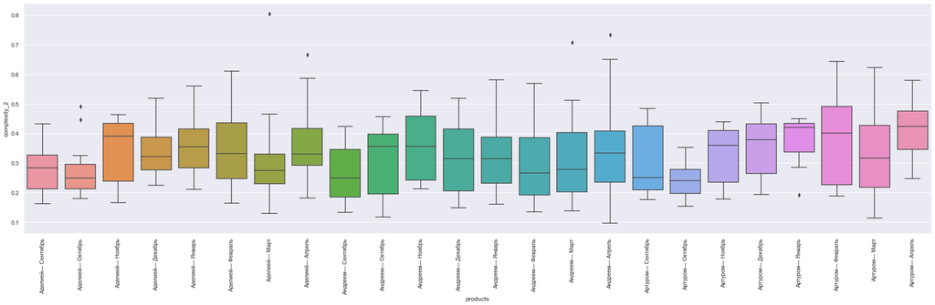

```python
ax = sns.boxplot(x = "products", y="complexity_2",
                 data=gr3_df)
sns.set(rc={'figure.figsize':(31.7,8.27)})
aray_of_ticks = plt.xticks(rotation=90)
```

### Из визуализации можно вынести пару соображений:

- У Андрея сложность занятий в среднем разбира более широко, то есть есть как лёгкие так и сложные уроки
- У Артура и Аделии есть откровенно лёгкий Октябрь
- В отличии от других преподавателей, у Артура довольно высокий разброс в сентябре, хотя и средний уровень сложности(горизонтальная линия внутри свечи) находится на том же уровне, что и у остальных. Этот феномен было бы интересно сравнить с "уходами" Артура и других преподавателей.